# [Retour à la page d’accueil](https://scortijo.github.io/ggplot_course/)

## Formation ggplot2 - solutions des exercices

> **Exercice:** Pouvez vous dessiner un violin plot? (indice: `?geom_violin`)

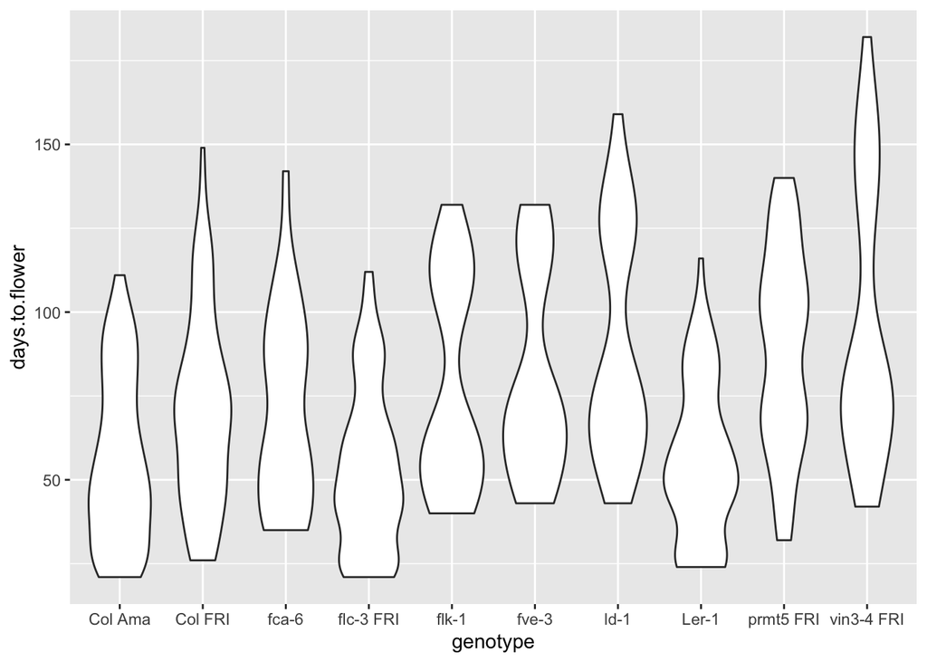

```r
ggplot(expt1, aes(genotype, days.to.flower)) +
  geom_violin()
```

> **Exercice:** Modifiez le graphique pour que les points soient devant plutôt que derrière les boxplots.

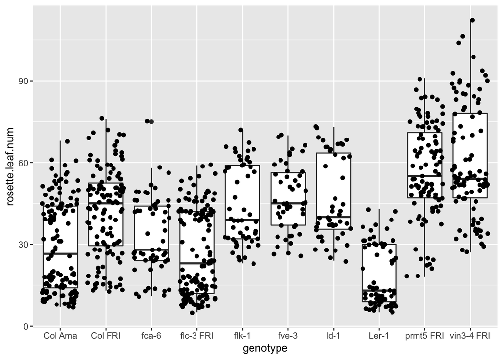

```r
ggplot(expt1, aes(genotype, rosette.leaf.num)) +
  geom_boxplot() +
  geom_jitter()
```

> **Exercice:** Nous voulons étudier la relation entre le nombre de feuille de rosette et la longueur la limbe des feuilles (en mm) pour les genotypes.

> Pour cela, dessinez un scatter plot (`geom_point()`) entre `blade.length.mm` et `rosette.leaf.num` en colorant les points en fonction de `genotype`.

> Que se passe t-il si les points sont colorés en fonction de `days.to.bolt`?

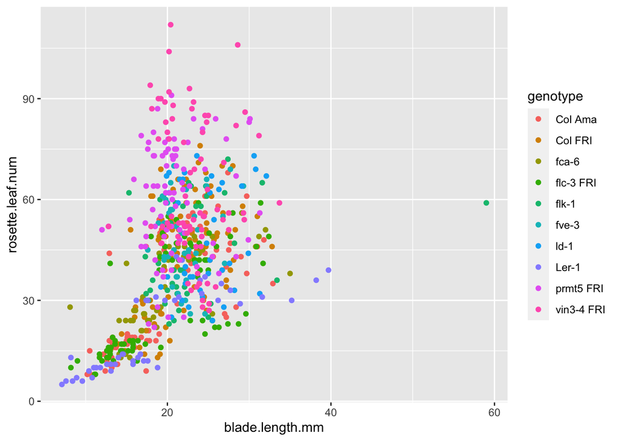

```r
ggplot(expt1, aes(blade.length.mm, rosette.leaf.num, colour = genotype)) +
  geom_point()
```

If we colour the points by `days.to.bolt` the colour scale is continuous rather than discrete (because `days.to.bolt` is a numeric variable):

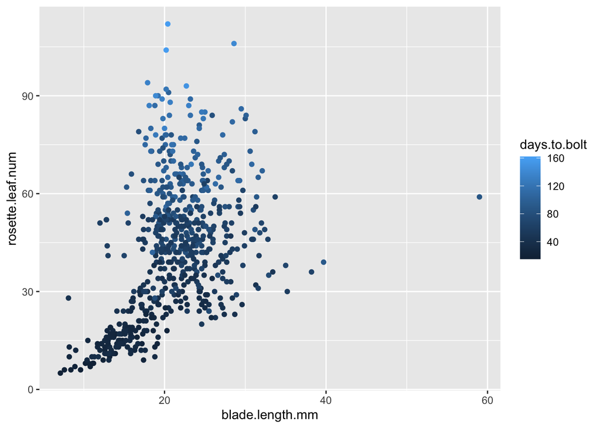

```r
ggplot(expt1, aes(blade.length.mm, rosette.leaf.num, colour = days.to.bolt)) +
  geom_point()
```

> **Exercice:** Les couleurs n’apportent plus d’information supplementaire. Pensez à une utilisation plus interessante des couleurs dans ce graphque.

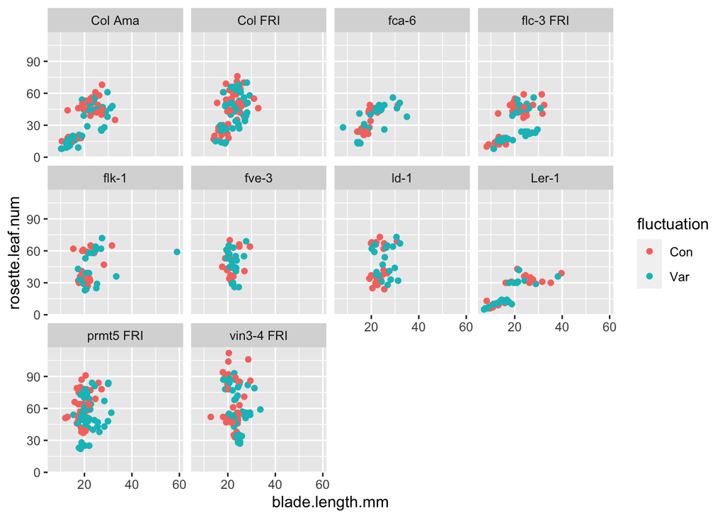

```r
ggplot(expt1, aes(blade.length.mm, rosette.leaf.num, colour = fluctuation)) +
    geom_point() +
    facet_wrap( ~ genotype)
```

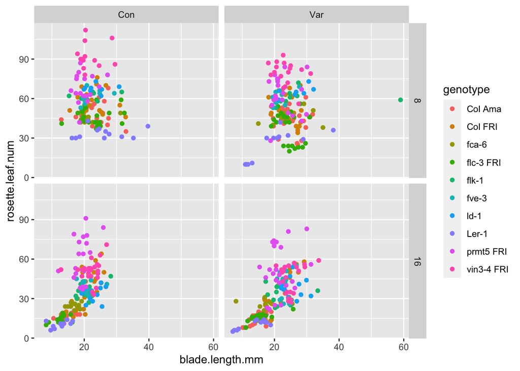

```r
ggplot(expt1, aes(blade.length.mm, rosette.leaf.num, colour = genotype)) +
    geom_point() +
    facet_grid(day.length ~ fluctuation)
```

> **Indice**: facet le graphique avec `day.length` et `temperature` et colorer l’intérieur des boxplot en fonction de `fluctuation`.

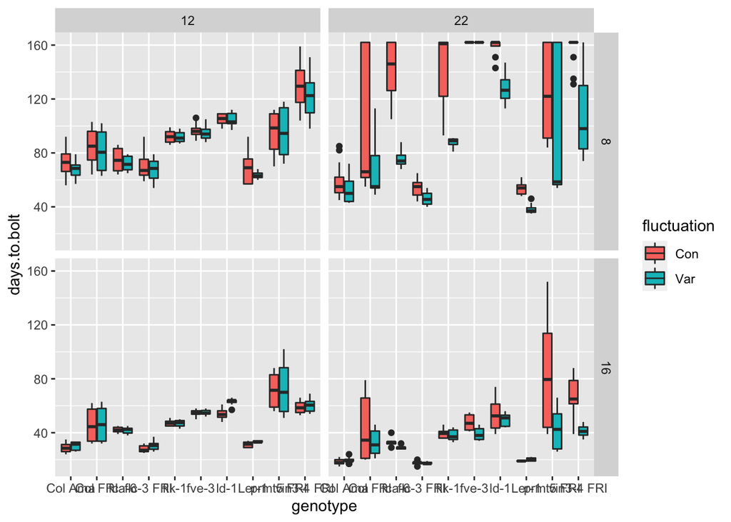

```r
ggplot(expt1, aes(genotype, days.to.bolt, fill = fluctuation)) +
    geom_boxplot() +
    facet_grid(day.length ~ temperature)
```